# Task 1: Data Import and Business understanding

# Task 8 Model Selcetion

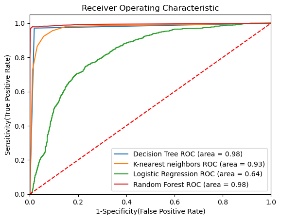

```python
#https://stackoverflow.com/questions/42894871/how-to-plot-multiple-roc-curves-in-one-plot-with-legend-and-auc-scores-in-python

plt.figure()

# Add the models to the list that you want to view on the ROC plot
models = [
{
    'label': 'Decision Tree',
    'model': DecisionTreeClassifier(),
},
{
    'label': 'K-nearest neighbors',
    'model': KNeighborsClassifier(),
},
{
    'label': 'Logistic Regression',
    'model': LogisticRegression(solver='lbfgs', max_iter=500),
},
{
    'label': 'Random Forest',
    'model': RandomForestClassifier(n_estimators=100),
}
]

# Below for loop iterates through your models list
for m in models:
    model = m['model'] # select the model
    model.fit(X_train, y_train) # train the model
    #y_pred=model.predict(X_test) # predict the test data

    # Compute False postive rate, and True positive rate
    fpr, tpr, thresholds = metrics.roc_curve(y_test, model.predict_proba(X_test)[:,1])

    # Calculate Area under the curve to display on the plot
    auc = metrics.roc_auc_score(y_test,model.predict(X_test))

    # Now, plot the computed values
    plt.plot(fpr, tpr, label='%s ROC (area = %0.2f)' % (m['label'], auc))

# Custom settings for the plot
plt.plot([0, 1], [0, 1],'r--')
plt.xlim([0.0, 1.0])
plt.ylim([0.0, 1.05])
plt.xlabel('1-Specificity(False Positive Rate)')
plt.ylabel('Sensitivity(True Positive Rate)')
plt.title('Receiver Operating Characteristic')
plt.legend(loc="lower right")
plt.show()   # Display
```

- 1. What is your best model? Explain the model.

-> The Best model based on the testing is Random Forest by 98.7% almot 99% because this model stands higest and considered best beacsue the the decision is made by building 20 decision trees and also another important feature is feature selection where it predicts w.r.t most important variable.

-> My second best model is Decision tree with almost 98% accuracy but when simplified its accuracy has reduced to 95.

-> Random Forest Classifier > Decision tree > KNN > Logistic regression.

- 2. How good is your model

-> The prediction is 99% acurate leaving very less false rate.

# Task 9 - Demonstrate your storytelling skills.

- 1. What are the results of testing your hypotheses?
- Satisfaction level w.r.t to employees who left
- average_monthly_hours w.r.t to employees who left

-> We reject null hypothesis in these 2 hypothesis cases because there is significant difference between employees who left and who stayed.

- last_evaluation w.r.t to employees who left

-> We fail to reject in this case beacuse there is no significant difference between employees who stayed and who left.

- 2. Discuss your classification model(s) for companies and HR managers. What variables are important in predicting employee turnover? And how important are they? What are the characteristics of the employees who are likely to leave?